# pkgdiff

```r
library(pkgdiff)
```

The purpose of **pkgdiff** is to identify changes between package versions, with the aim of assessing package stability. Here is a list of the major functions in **pkgdiff**, and a short explanation of each:

- `pkg_info()`: Displays general information about a package, including the description, maintainer, and number of downloads in the last month.
- `pkg_versions()`: Returns a data frame of all versions of a package.
- `pkg_diff()`: Compares two versions of a package, and shows which functions and parameters have been added or removed.
- `pkg_stability()`: Looks at the history of a package, identifies breaking changes, and assesses the package for stability.
- `pkg_summary()`: Creates an HTML summary of information about a package, and sends it to the RStudio viewer.
- `pkg_repo()`: Generates a table of the packages in a repository and their versions.
- `repo_breakages()`: Looks at a package repository and tries to identify which packages will break when upgraded.
- `repo_stability()`: Looks at a package repository and calculates a stability score for each package.

Below is a further elaboration and demo for each of the above functions.

## General Package Information

The first thing you may want to do when exploring a package is to get some general information about it. General information about a package can be achieved using the `pkg_info()` function. All you need to pass is the package name. The function will then return basic information such as the maintainer, description, and imported packages. Here is a simple demonstration:

```r
# Examine tidymodels package
pkg_info("tidymodels")
# # A package info object: tidymodels package
# - Version: v1.2.0
# - Release Date: 2024-03-25
# - Title: Easily Install and Load the 'Tidymodels' Packages
# - Maintainer: Max Kuhn <max@posit.co>
# - License: MIT + file LICENSE
# - Description: The tidy modeling "verse" is a collection of packages for
# modeling and statistical analysis that share the underlying design
# philosophy, grammar, and data structures of the tidyverse.
# - Depends: R (>= 3.6)
# - Imports: broom (>= 1.0.5), cli (>= 3.6.2), conflicted (>= 1.2.0),
# dials (>= 1.2.1), dplyr (>= 1.1.4), ggplot2 (>= 3.5.0), hardhat (>= 1.3.1),
# infer (>= 1.0.6), modeldata (>= 1.3.0), parsnip (>= 1.2.1), purrr (>= 1.0.2),
# recipes (>= 1.0.10), rlang (>= 1.1.3), rsample (>= 1.2.1), rstudioapi (>= 0.16.0),
# tibble (>= 3.2.1), tidyr (>= 1.3.1), tune (>= 1.2.0), workflows (>= 1.1.4),
# workflowsets (>= 1.1.0), yardstick (>= 1.3.1)
# - Suggests: covr, glue, knitr, rmarkdown, testthat (>= 3.0.0), xml2
# - Repository: CRAN
# - Cached: TRUE
# - Functions: 9
```

The return value of this function is actually an object that can be manipulated programmatically. Here we will extract some of the data values from this object:

```r
# Capture package info object
res <- pkg_info("tidymodels")

# View version
res$Version
# [1] "1.3.0"

# View title
res$Title
# [1] "Easily Install and Load the 'Tidymodels' Packages"

# View release date
res$ReleaseDate
# [1] "2025-02-21"
```

Note that, by default, the version of the package returned is the version of the package located on the current machine, in the current version of the R repository. If the package is not installed in the current R repository, the function will return the latest version on CRAN.

Also note that the object provides a complete list of all functions exported by the package. The function list can be accessed programmatically, and also viewed using the `verbose` parameter of the `print()` function:

```r
# Get package info
res <- pkg_info("tidymodels")

# View functions
print(res, verbose = TRUE)
# # A package info object: tidymodels package
# - Version: v1.3.0
# - Release Date: 2025-02-21
# - Title: Easily Install and Load the 'Tidymodels' Packages
# - Maintainer: Max Kuhn <max@posit.co>
# - License: MIT + file LICENSE
# - Description: The tidy modeling "verse" is a collection of packages for
# modeling and statistical analysis that share the underlying design
# philosophy, grammar, and data structures of the tidyverse.
# - Depends: R (>= 3.6)
# - Imports: broom (>= 1.0.7), cli (>= 3.6.4), conflicted (>= 1.2.0),
# dials (>= 1.4.0), dplyr (>= 1.1.4), ggplot2 (>= 3.5.1), hardhat (>= 1.4.1),
# infer (>= 1.0.7), modeldata (>= 1.4.0), parsnip (>= 1.3.0), purrr (>= 1.0.4),
# recipes (>= 1.1.1), rlang (>= 1.1.5), rsample (>= 1.2.1), rstudioapi (>= 0.17.1),
# tibble (>= 3.2.1), tidyr (>= 1.3.1), tune (>= 1.3.0), workflows (>= 1.2.0),
# workflowsets (>= 1.1.0), yardstick (>= 1.3.2)
# - Suggests: covr, glue, knitr, rmarkdown, testthat (>= 3.0.0), xml2
# - Downloads/Month: 31789
# - Repository: CRAN
# - Cached: TRUE
# - Functions:
#   - pkg_deps(): x, recursive
#   - print.tidymodels_conflicts(): x, ..., startup
#   - tag_attach(): tag
#   - tag_show()
#   - tag_update(): tag
#   - tidymodels_conflicts()
#   - tidymodels_packages(): include_self
#   - tidymodels_prefer(): quiet
#   - tidymodels_update(): pkg, recursive, ...
```

## Stability Assessment

Besides general information about a package, you may also view the “stability” of a package. The `pkg_stability()` function looks at the entire history of the package, and attempts to assess its overall stability in terms of breaking changes. Here, a “breaking change” means either a removed function or removed function parameter. The `pkg_stability()` function is very useful when you are writing production code, and want to select the most stable packages possible. The results of this function can help you make that determination:

```r
# View package stability
pkg_stability("tidymodels")
# # A stability score: tidymodels package
# - Age: 6.58 years
# - Score: 100.0
# - Assessment: Perfect
# - Version Range: 0.0.1/1.3.0
# - Release Range: 2018-07-27/2025-02-21
# - Release Count: 14
# - Breaking Releases: 0
# - Data:
#       Package Version                FileName    Release  Size AF AP RF RP BC TF
# 1  tidymodels   1.3.0 tidymodels_1.3.0.tar.gz 2025-02-21 46.4K  0  0  0  0  0  9
# 2  tidymodels   1.2.0 tidymodels_1.2.0.tar.gz 2024-03-25 49.6K  0  0  0  0  0  9
# 3  tidymodels   1.1.1 tidymodels_1.1.1.tar.gz 2023-08-24   50K  0  0  0  0  0  9
# 4  tidymodels   1.1.0 tidymodels_1.1.0.tar.gz 2023-05-01   49K  0  0  0  0  0  9
# 5  tidymodels   1.0.0 tidymodels_1.0.0.tar.gz 2022-07-13   75K  0  0  0  0  0  9
# 6  tidymodels   0.2.0 tidymodels_0.2.0.tar.gz 2022-03-19   75K  0  0  0  0  0  9
# 7  tidymodels   0.1.4 tidymodels_0.1.4.tar.gz 2021-10-01   17K  0  0  0  0  0  9
# 8  tidymodels   0.1.3 tidymodels_0.1.3.tar.gz 2021-04-19   15K  1  0  0  0  0  9
# 9  tidymodels   0.1.2 tidymodels_0.1.2.tar.gz 2020-11-22   26K  0  0  0  0  0  8
# 10 tidymodels   0.1.1 tidymodels_0.1.1.tar.gz 2020-07-14   25K  0  0  0  0  0  8
# 11 tidymodels   0.1.0 tidymodels_0.1.0.tar.gz 2020-02-16   57K  0  0  0  0  0  8
# 12 tidymodels   0.0.3 tidymodels_0.0.3.tar.gz 2019-10-05   19K  0  0  0  0  0  8
# 13 tidymodels   0.0.2 tidymodels_0.0.2.tar.gz 2018-11-27   18K  0  0  0  0  0  8
# 14 tidymodels   0.0.1 tidymodels_0.0.1.tar.gz 2018-07-27   18K  8  8  0  0  0  8
```

The stability score is calculated generally as the percentage of non-breaking releases. Breaking releases are also weighted to reduce their impact over time. The above score of 100 for **tidymodels** means that the package has never had a breaking change. It is therefore given a stability assessment of “Perfect”.

Now let’s look at a package with some breaking changes:

```r
# View package stability
pkg_stability("dbplyr")
# # A stability score: dbplyr package
# - Age: 7.67 years
# - Score: 73.7
# - Assessment: Unstable
# - Version Range: 1.0.0/2.5.0
# - Release Range: 2017-06-09/2024-03-19
# - Release Count: 23
# - Breaking Releases: 10
# - Data:
#    Package Version            FileName    Release   Size  AF  AP RF RP BC  TF
# 1   dbplyr   2.5.0 dbplyr_2.5.0.tar.gz 2024-03-19 752.6K  32   6 12  0  1 611
# 2   dbplyr   2.4.0 dbplyr_2.4.0.tar.gz 2023-10-26   743K  74  80 45 33  1 591
# 3   dbplyr   2.3.4 dbplyr_2.3.4.tar.gz 2023-09-27   706K   0   0  0  0  0 562
# 4   dbplyr   2.3.3 dbplyr_2.3.3.tar.gz 2023-07-07   706K   0   0  0  0  0 562
# 5   dbplyr   2.3.2 dbplyr_2.3.2.tar.gz 2023-03-21   707K   0   1  0  1  1 562
# 6   dbplyr   2.3.1 dbplyr_2.3.1.tar.gz 2023-02-24   707K   5   6  1  0  1 562
# 7   dbplyr   2.3.0 dbplyr_2.3.0.tar.gz 2023-01-16   688K  33  16  5  1  1 558
# 8   dbplyr   2.2.1 dbplyr_2.2.1.tar.gz 2022-06-27   655K   4   0  0  0  0 530
# 9   dbplyr   2.2.0 dbplyr_2.2.0.tar.gz 2022-06-05   655K 136  47 53  1  1 526
# 10  dbplyr   2.1.1 dbplyr_2.1.1.tar.gz 2021-04-06   568K   5   0  0  0  0 443
# 11  dbplyr   2.1.0 dbplyr_2.1.0.tar.gz 2021-02-03   566K  15   2  0  0  0 438
# 12  dbplyr   2.0.0 dbplyr_2.0.0.tar.gz 2020-11-03   522K 139  33 94 11  1 423
# 13  dbplyr   1.4.4 dbplyr_1.4.4.tar.gz 2020-05-27   417K   5   0  0  0  0 378
# 14  dbplyr   1.4.3 dbplyr_1.4.3.tar.gz 2020-04-19   413K   9   3  2  2  1 373
# 15  dbplyr   1.4.2 dbplyr_1.4.2.tar.gz 2019-06-17   296K   1   0  0  0  0 366
# 16  dbplyr   1.4.1 dbplyr_1.4.1.tar.gz 2019-06-06   296K   1   0  0  0  0 365
# 17  dbplyr   1.4.0 dbplyr_1.4.0.tar.gz 2019-04-24   295K  24  30 17 13  1 364
# 18  dbplyr   1.3.0 dbplyr_1.3.0.tar.gz 2019-01-09   263K   2   0  0  0  0 357
# 19  dbplyr   1.2.2 dbplyr_1.2.2.tar.gz 2018-07-25   258K   0   0  0  0  0 355
# 20  dbplyr   1.2.1 dbplyr_1.2.1.tar.gz 2018-02-19   257K   0   0  0  0  0 355
# 21  dbplyr   1.2.0 dbplyr_1.2.0.tar.gz 2018-01-03   257K  43   6  2  2  1 355
# 22  dbplyr   1.1.0 dbplyr_1.1.0.tar.gz 2017-06-27   241K  23   2  0  0  0 314
# 23  dbplyr   1.0.0 dbplyr_1.0.0.tar.gz 2017-06-09   235K 291 291  0  0  0 291
```

As seen above, the **dbplyr** package has had a lot of breaking changes. Which releases had breaking changes are shown in the “BC” column of the data grid. The “AF” and “AP” columns stand for “Added Functions” and “Added Parameters”, while “RF” and “RP” mean “Removed Functions” and “Removed Parameters”. “TF” is the total number of exported functions in that version of the package.

Since this package has issued breaking changes in 10 out of 23 releases, it gets a stability score of 73.7, and an assessment of “Unstable”. A stability assessment of “Unstable” does not necessarily mean you should not use the package. Whether or not you use the package depends on your situation, and the amount of risk you can tolerate.

## Create a Summary Report

The information from the above functions can also be combined into a nice report using `pkg_summary()`. `pkg_summary()` pulls key data from `pkg_info()` and `pkg_stability()` and generates an HTML page, which it then sends to the RStudio viewer.

For example, you can run a package summary report for the **dplyr** package like this:

```r
# Get package summary report
pkg_summary("dplyr")
```

The following will then appear in the RStudio viewer:

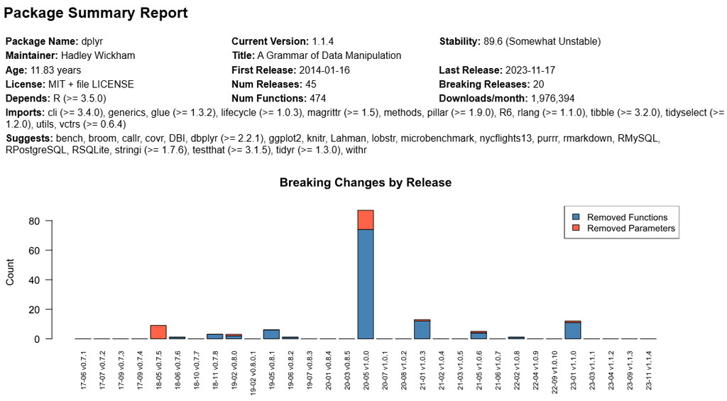

The chart shows the number of breaking changes per release. As you can see, the **dplyr** package had a large number of breaking changes between version “0.8.5” and version “1.0.0”, but has been relatively stable since then.

The Package Summary Report provides an easy way to get an overview of a package. For additional information, see the `pkg_summary()` documentation.

## Comparing Package Versions

If you find a package with breaking changes, you would then want to know what those breaking changes are. The breaking changes between package versions can be discovered with the `pkg_diff()` function. This function accepts a package name, and the two versions of the package you wish to compare.

Looking at our stability data above, let’s examine the breaking changes between versions “2.4.0” and “2.5.0” of **dbplyr**:

```r
# Compare package versions
pkg_diff("dbplyr", "2.4.0", "2.5.0")
# # A difference object: dbplyr package
# - Comparing: v2.4.0/v2.5.0
# - Breaking Changes: TRUE
# - Added Functions:
#   - [.dbplyr_table_path()
#   - [[.dbplyr_table_path()
#   - as_table_path()
#   - c.dbplyr_table_path()
#   - check_table_path()
#   - complete.tbl_lazy()
#   - db_explain.Oracle()
#   - db_explain.OraConnection()
#   - db_sql_render.Microsoft SQL Server()
#   - escape.dbplyr_table_path()
#   - escape.default()
#   - expand.tbl_lazy()
#   - fill.tbl_lazy()
#   - group_by_drop_default.tbl_lazy()
#   - intersect.tbl_lazy()
#   - is_table_path()
#   - pivot_longer.tbl_lazy()
#   - pivot_wider.tbl_lazy()
#   - print.dbplyr_table_path()
#   - reframe.tbl_lazy()
#   - replace_na.tbl_lazy()
#   - setdiff.OraConnection()
#   - setdiff.tbl_lazy()
#   - setdiff.tbl_Oracle()
#   - simulate_mariadb()
#   - sql_escape_ident.default()
#   - sql_escape_ident.MySQLConnection()
#   - sql_escape_string.default()
#   - table_path_components()
#   - table_path_components.default()
#   - table_path_name()
#   - union.tbl_lazy()
# - Added Parameters:
#   - flatten_query.base_query(): con
#   - flatten_query.multi_join_query(): con
#   - flatten_query.select_query(): con
#   - flatten_query.union_query(): con
#   - flatten_query.values_query(): con
#   - sql_translation.MySQL(): con
# - Removed Functions:
#   - as_table_ident.character()
#   - as_table_ident.dbplyr_catalog()
#   - as_table_ident.dbplyr_schema()
#   - as_table_ident.dbplyr_table_ident()
#   - as_table_ident.Id()
#   - as_table_ident.ident()
#   - as_table_ident.ident_q()
#   - as_table_ident.sql()
#   - escape.dbplyr_table_ident()
#   - format.dbplyr_table_ident()
#   - sql_escape_ident.DBIConnection()
#   - sql_escape_string.DBIConnection()
```

As you can see, many new functions and function parameters have been added between these two versions. In addition, there are 12 functions that have been removed. It is up to you to determine whether and how these removals will affect your programs. It is very convenient, however, to have an accurate accounting of package changes. These changes can help you plan your package upgrades and anticipate breakages.

## Listing Package Versions

Another question you may ask when evaluating a package is: How many versions of a package are there? **pkgdiff** provides two tools to find version information: `pkg_versions()` and `pkg_repo()`.

`pkg_versions()` returns all the versions of a package in a data frame, along with release dates for each version. It works like this:

```r
# Get package versions
pkg_versions("stringr")
#    Package Version              FileName    Release   Size
# 1  stringr   1.5.1  stringr_1.5.1.tar.gz 2023-11-14   172K
# 2  stringr   1.5.0  stringr_1.5.0.tar.gz 2022-12-02   172K
# 3  stringr   1.4.1  stringr_1.4.1.tar.gz 2022-08-21   133K
# 4  stringr   1.4.0  stringr_1.4.0.tar.gz 2019-02-10   133K
# 5  stringr   1.3.1  stringr_1.3.1.tar.gz 2018-05-10   116K
# 6  stringr   1.3.0  stringr_1.3.0.tar.gz 2018-02-19   116K
# 7  stringr   1.2.0  stringr_1.2.0.tar.gz 2017-02-18    92K
# 8  stringr   1.1.0  stringr_1.1.0.tar.gz 2016-08-19    62K
# 9  stringr   1.0.0  stringr_1.0.0.tar.gz 2015-04-30    34K
# 10 stringr   0.6.2  stringr_0.6.2.tar.gz 2012-12-06    20K
# 11 stringr   0.6.1  stringr_0.6.1.tar.gz 2012-07-25    20K
# 12 stringr     0.6    stringr_0.6.tar.gz 2011-12-08    20K
# 13 stringr     0.5    stringr_0.5.tar.gz 2011-06-30    18K
# 14 stringr     0.4    stringr_0.4.tar.gz 2010-08-24    16K
# 15 stringr     0.3    stringr_0.3.tar.gz 2010-02-15    11K
# 16 stringr     0.2    stringr_0.2.tar.gz 2009-11-16    10K
# 17 stringr  0.1.10 stringr_0.1.10.tar.gz 2009-11-09   6.8K
```

Observe that the **stringr** package has had 17 releases. The first release was in 2009, and the most recent in 2023. This information is scraped from the CRAN archive site. It is useful for understanding the release history of a package, and knowing which versions of a package are available.

Next, you may want to know which versions of packages you have installed in your R repository. This information can be queried using the `pkg_repo()` function. Let’s take a look:

```r
# Check version in repo
pkg_repo("stringr")
# # A package repo object
# - Repo Version: 4.4
# - Packages:
#   Package Version
# 1 stringr   1.5.1
```

Base on the above information, it appears we have the latest version of **stringr** installed in our R 4.4 repo. Good to know!

Can `pkg_repo()` be used to get versions for multiple packages? Yes! Here is how:

```r
# Create vector of packages
v1 <- c("curl", "dplyr", "fmtr", "purrr")

# Get current versions
res1 <- pkg_repo(v1, ver = "current")

# View results
res1
# # A package repo object
# - Repo Version: 4.4
# - Packages:
#   Package Version
# 1    curl   5.2.1
# 2   dplyr   1.1.4
# 3    fmtr   1.6.5
# 4   purrr   1.0.2

# Get latest versions
res2 <- pkg_repo(v1, ver = "latest")

# View results
res2
# # A package repo object
# - Repo Version: latest
# - Packages:
#   Package Version
# 1    curl   6.2.1
# 2   dplyr   1.1.4
# 3    fmtr   1.6.8
# 4   purrr   1.0.4
```

Moreover, if you run `pkg_repo()` without any parameters, it will return all the R packages you have installed, along with their versions. Nice!

The `pkg_repo()` function is very useful when dealing with large numbers of packages. This function feeds directly into the next two topics, which discuss operations on entire repositories.

## Anticipating Breakages

One of the main motivations for creating **pkgdiff** was to find a way to better handle repository upgrades. As it stands, repository upgrades can be a chaotic experience. When you have several hundred packages in your repository, you will surely have some of them break when you go to upgrade. Wouldn’t it be nice to at least know which packages are going to break? That is the topic of this next section.

### Small Set of Packages

First, let’s see how we can anticipate breaking changes on a small number of packages.

For this exercise, we will use the `res1` and `res2` data frames from the previous section. These data frames were created using `pkg_repo()`, and contain version numbers for four R packages. These data frames are in fact perfect inputs to our next function: `repo_breakages()`.

The `repo_breakages()` function can compare packages in bulk. It will perform difference operations on any number of packages, and tell you whether or not there will be any breaking changes. As you can imagine, this function is well suited for repository upgrades. Here is an example:

```r
# View upgrade breakages
repo_breakages(res1, res2)
# Comparing curl v5.2.1/v6.2.0
# Comparing fmtr v1.6.5/v1.6.8
# Comparing purrr v1.0.2/v1.0.4
# # A repo breakages object
# - Run Datetime: 2025-03-01 17:58 UTC
# - Summary:
#   Package Version1 Version2 Breakages
# 1    curl    5.2.1    6.2.1      TRUE
# 2   dplyr    1.1.4    1.1.4     FALSE
# 3    fmtr    1.6.5    1.6.8     FALSE
# 4   purrr    1.0.2    1.0.4     FALSE
# - Details:
# # A difference object: curl package
# - Comparing: v5.2.1/v6.2.1
# - Breaking Changes: TRUE
# - Added Functions: 1
# - Added Parameters: 3
# - Removed Parameters:
#   - multi_download(): timeout
```

The `repo_breakages()` function returns a list with two major items: “Summary” and “Details”. The “Summary” item is a data frame showing the input packages, the input package versions, and a TRUE or FALSE flag that describes whether there are any breaking changes between the two package versions. The “details” list item then provides the difference object for any package that had a breaking change. This function tells you exactly what you need to know before a repository upgrade. If desired, you can then use the difference information to scan your code, and determine whether those removals will break anything.

### Entire Repository

The above demonstration showed how to use `repo_breakages()` on a small number of packages. Now let’s see how to use the function on a large number of packages. In fact, we will perform an upgrade analyse on our entire R repository:

```r
# Get current versions from local repo
r1 <- pkg_repo(ver = "current")

# View Results
r1
# # A package repo object
# - Repo Version: 4.2
# - Packages:
#            Package              Version
# 1            abind                1.4-5
# 2          admiral               0.10.1
# 3       admiraldev                0.3.0
# 4      admiralonco                0.3.0
# 5             ards                0.1.0
# 6            arrow             11.0.0.3
# 7          askpass                  1.1
# 8       assertthat                0.2.1
# 9           aws.s3               0.3.21
# 10   aws.signature                0.6.0
# 11       backports                1.4.1
# 12       base64enc                0.1-3
# 13             bit                4.0.4
# 14           bit64                4.0.5
# 15          bitops                1.0-7
# 16            blob                1.2.3
# ...

# Get latest versions of current repo on CRAN
r2 <- pkg_repo(r1$Package, ver = "latest")

# View Results
r2
# # A package repo object
# - Repo Version: latest
# - Packages:
#            Package    Version
# 1            abind      1.4-8
# 2          admiral      1.2.0
# 3       admiraldev      1.2.0
# 4      admiralonco      1.2.0
# 5             ards      0.1.1
# 6            arrow   18.1.0.1
# 7          askpass      1.2.1
# 8       assertthat      0.2.1
# 9           aws.s3     0.3.21
# 10   aws.signature      0.6.0
# 11       backports      1.5.0
# 12       base64enc      0.1-3
# 13             bit    4.5.0.1
# 14           bit64    4.6.0-1
# 15          bitops      1.0-9
# 16            blob      1.2.4
# ...


# Check for breakages on whole repository
res <- repo_breakages(r1, r2)
# Comparing abind v1.4-5/v1.4-8
# Comparing admiral v0.10.1/v1.2.0
# Comparing admiraldev v0.3.0/v1.2.0
# Comparing admiralonco v0.3.0/v1.2.0
# Comparing ards v0.1.0/v0.1.1
# Archive versions of 'ards' not available.
# Comparing arrow v11.0.0.3/v18.1.0.1
# Comparing askpass v1.1/v1.2.1
# Comparing backports v1.4.1/v1.5.0
# Comparing bit v4.0.4/v4.5.0.1
# Comparing bit64 v4.0.5/v4.6.0-1
# Comparing bitops v1.0-7/v1.0-9
# Comparing blob v1.2.3/v1.2.4
# Comparing box v1.1.3/v1.2.0
# Comparing brew v1.0-8/v1.0-10
# Comparing brio v1.1.3/v1.1.5
# Comparing broom v1.0.1/v1.0.7
# Comparing bslib v0.4.0/v0.9.0
# Comparing cachem v1.0.6/v1.1.0
# Comparing callr v3.7.3/v3.7.6
# ...
```

When the processing finishes, you can examine the results using dollar sign ($) notation:

```r
# View Summary Table
res$Summary
#            Package             Version1   Version2 Breakages
# 1            abind                1.4-5      1.4-8     FALSE
# 2          admiral               0.10.1      1.2.0      TRUE
# 3       admiraldev                0.3.0      1.2.0      TRUE
# 4      admiralonco                0.3.0      1.2.0      TRUE
# 5             ards                0.1.0      0.1.1        NA
# 6            arrow             11.0.0.3   18.1.0.1     FALSE
# 7          askpass                  1.1      1.2.1     FALSE
# 8       assertthat                0.2.1      0.2.1     FALSE
# 9           aws.s3               0.3.21     0.3.21     FALSE
# 10   aws.signature                0.6.0      0.6.0     FALSE
# 11       backports                1.4.1      1.5.0     FALSE
# 12       base64enc                0.1-3      0.1-3     FALSE
# 13             bit                4.0.4    4.5.0.1     FALSE
# 14           bit64                4.0.5    4.6.0-1      TRUE
# 15          bitops                1.0-7      1.0-9     FALSE
# 16            blob                1.2.3      1.2.4     FALSE
# ...

# View Difference Details
res$Details$admiralonco
# # A difference object: admiralonco package
# - Comparing: v0.3.0/v1.2.0
# - Breaking Changes: TRUE
# - Added Functions:
#   - bor_cr()
#   - bor_ne()
#   - bor_non_crpd()
#   - bor_pd()
#   - bor_pr()
#   - bor_sd()
#   - cb_y()
#   - cbor_cr()
#   - cbor_pr()
#   - crsp_y_cr()
#   - crsp_y_pr()
#   - no_data_missing()
#   - no_data_n()
#   - rsp_y()
# - Removed Functions:
#   - call_aval_fun()
#   - derive_param_lasta()
```

What is convenient is that you can run these functions before any new package versions are downloaded and installed.  
They work on archive packages stored on CRAN, not on your local machine. In this way, prior to any actual upgrade, you can make a determination as to a) whether to proceed with the upgrade or not, and b) how much effort it might take to fix any breakages.

## Assessing Entire Repository

In addition to anticipating breakages for a large number of packages, **pkgdiff** also allows you to gather stability scores for a large number of packages. Bulk stability scores are achieved using `repo_stability()`. Here is how to do it:

```r
# Create vector of packages
v1 <- c("curl", "dplyr", "dbplyr", "purrr")

# Assess stability
res <- repo_stability(v1)
# Getting stability score for package 'curl'...
# Getting stability score for package 'dplyr'...
# Getting stability score for package 'dbplyr'...
# Getting stability score for package 'purrr'...

# View results
res
# # A repo stability object
# - Run Datetime: 2025-03-01 17:46 UTC
# - Summary:
#   Package    FV    LV         FR         LR TR BR Score        Assessment
# 1    curl   0.2 6.2.1 2014-11-20 2025-02-19 51  1  98.0       Very Stable
# 2   dplyr   0.1 1.1.4 2014-01-16 2023-11-17 45 20  87.5 Somewhat Unstable
# 3  dbplyr 1.0.0 2.5.0 2017-06-09 2024-03-19 23 10  74.1          Unstable
# 4   purrr 0.1.0 1.0.4 2015-09-28 2025-02-05 18  6  92.1            Stable
```

The above result shows each package on the input vector, the first and last versions, the first and last release dates, and the total number of releases. It also shows the number of breaking releases, a stability score, and a stablity assessment for each package. This information is very helpful to get an overall sense of the stability of your repository, and where breaking changes might occur when they do.

Like `repo_breakages()`, `repo_stability()` can be used to assess an entire repository. Simply use `pkg_repo()` to get the packages in your current repo, and pass the “Packages” column into `repo_stability()`. Remember to give `repo_stability()` plenty of uninterrupted processing time if you are assessing a large number of packages.

## Next Steps

For addition research on **pkgdiff**, you may wish to browse the following articles:

- Stability Score
- Package Cache
- Frequently Asked Questions